# Scoping

```python
import os
from io import BytesIO, StringIO
from pathlib import Path

import boto3
import botocore.exceptions
import pandas as pd
from dotenv import load_dotenv
```

```python
PROJ_ROOT = Path.cwd().parent
```

```python
assert load_dotenv(dotenv_path=PROJ_ROOT.parent / '.env')
```

## About

Project scoping using the full random sample of data for ~10,000 customers from McMaster Bank.

## User Inputs

```python
# R2 data bucket details
bucket_name = 'cc-churn-splits'

# columns to load for project scoping tasks
columns = [
    'clientnum',
    'card_category',
    'total_revolv_bal',
    'total_trans_amt',
    'is_churned',
]

# costs
# # revenue from transactions (bank earns #% of transaction volume)
interchange_rate = 0.02
# # revenue from revolving balance (~20% interest)
apr = 0.18
# # fee revenue from credit card exposure (modeled from card type)
card_fees = {"Blue": 0, "Silver": 50, "Gold": 100, "Platinum": 200}
tenure_years = 3
discount = 0.9
# # percentage of churners who can be convinced to stay (i.e. success rate
# # of saving a churning customer)
success_rate = 0.40
# # cost of intervention to get a single customer to not churn (discounts,
# # call center time, retention offers, etc.)
intervention_cost = 50
# # cost of acquiring a new customer (Customer Acquisition Cost, CAC)
replacement_cost = 200
```

```python
account_id = os.getenv('ACCOUNT_ID')
access_key_id = os.getenv('ACCESS_KEY_ID')
secret_access_key = os.getenv('SECRET_ACCESS_KEY')

s3_client = boto3.client(
    's3',
    endpoint_url=f'https://{account_id}.r2.cloudflarestorage.com',
    aws_access_key_id=access_key_id,
    aws_secret_access_key=secret_access_key,
    region_name='auto'
)

multiplier = (1 - discount**tenure_years) / (1 - discount)
```

## Load Data

```python
%%time
prefix = ''
dfs = []
response = s3_client.list_objects_v2(Bucket=bucket_name, Prefix=prefix)
for obj in response.get('Contents', []):
    if (
        not obj['Key'].endswith('/')
        and '/' not in obj['Key'][len(prefix):]
        and obj['Key'].endswith('_data.parquet.gzip')
    ):
        obj = s3_client.get_object(Bucket=bucket_name, Key=obj['Key'])
        df = pd.read_parquet(BytesIO(obj['Body'].read()), columns=columns)
        dfs.append(df)
df = pd.concat(dfs, ignore_index=True).astype({"is_churned": 'bool[pyarrow]'})
df
```

```
CPU times: user 103 ms, sys: 9.97 ms, total: 113 ms
Wall time: 759 ms
```

|  | clientnum | card_category | total_revolv_bal | total_trans_amt | is_churned |
| --- | --- | --- | --- | --- | --- |
| 0 | 708223383 | Blue | 979.0 | 2736.0 | True |
| 1 | 715052583 | Silver | 879.0 | 14375.0 | False |
| 2 | 719910333 | Blue | 1190.0 | 3595.0 | False |
| 3 | 785328408 | Blue | 1180.0 | 2013.0 | False |
| 4 | 716321583 | Blue | 1173.0 | 3441.0 | False |
| ... | ... | ... | ... | ... | ... |
| 10122 | 804840033 | Blue | 0.0 | 1960.0 | False |
| 10123 | 786566733 | Blue | 1190.0 | 3764.0 | False |
| 10124 | 711326583 | Blue | 0.0 | 4274.0 | False |
| 10125 | 718538958 | Blue | 0.0 | 4564.0 | False |
| 10126 | 714051033 | Blue | 1699.0 | 1967.0 | False |

10127 rows × 5 columns

## Calculate Impact of Churn

Calculate customer lifetime value (CLV)

```python
%%time
df = df.assign(
    interchange_rev=lambda df: df["total_trans_amt"] * interchange_rate,
    interest_rev=lambda df: df["total_revolv_bal"] * apr,
    fee_rev=lambda df: (
        df["card_category"].map(card_fees).astype('int16[pyarrow]')
    ),
    annual_rev=lambda df: (
        df["interchange_rev"] + df["interest_rev"] + df["fee_rev"]
    ),
    clv=lambda df: df["annual_rev"] * multiplier,
    intervention_cost=intervention_cost,
)
df
```

```
CPU times: user 4.85 ms, sys: 2.88 ms, total: 7.73 ms
Wall time: 6.52 ms
```

|  | clientnum | card_category | total_revolv_bal | total_trans_amt | is_churned | interchange_rev | interest_rev | fee_rev | annual_rev | clv | intervention_cost |
| --- | --- | --- | --- | --- | --- | --- | --- | --- | --- | --- | --- |
| 0 | 708223383 | Blue | 979.0 | 2736.0 | True | 54.72 | 176.22 | 0 | 230.94 | 625.8474 | 50 |
| 1 | 715052583 | Silver | 879.0 | 14375.0 | False | 287.5 | 158.22 | 50 | 495.72 | 1343.4012 | 50 |
| 2 | 719910333 | Blue | 1190.0 | 3595.0 | False | 71.9 | 214.2 | 0 | 286.1 | 775.331 | 50 |
| 3 | 785328408 | Blue | 1180.0 | 2013.0 | False | 40.26 | 212.4 | 0 | 252.66 | 684.7086 | 50 |
| 4 | 716321583 | Blue | 1173.0 | 3441.0 | False | 68.82 | 211.14 | 0 | 279.96 | 758.6916 | 50 |
| ... | ... | ... | ... | ... | ... | ... | ... | ... | ... | ... | ... |
| 10122 | 804840033 | Blue | 0.0 | 1960.0 | False | 39.2 | 0.0 | 0 | 39.2 | 106.232 | 50 |
| 10123 | 786566733 | Blue | 1190.0 | 3764.0 | False | 75.28 | 214.2 | 0 | 289.48 | 784.4908 | 50 |
| 10124 | 711326583 | Blue | 0.0 | 4274.0 | False | 85.48 | 0.0 | 0 | 85.48 | 231.6508 | 50 |
| 10125 | 718538958 | Blue | 0.0 | 4564.0 | False | 91.28 | 0.0 | 0 | 91.28 | 247.3688 | 50 |
| 10126 | 714051033 | Blue | 1699.0 | 1967.0 | False | 39.34 | 305.82 | 0 | 345.16 | 935.3836 | 50 |

10127 rows × 11 columns

The class imbalance is shown below

```python
%%time
df_attrition_rate = (
    df['is_churned']
    .value_counts(normalize=True)
    .mul(100)
    .reset_index()
    .rename(columns={"is_churned": "attrition"})
    .assign(
        attrition=lambda df: df['attrition'].map(
            {False: 'No Churn', True: 'Churn'}
        )
    )
    .query("attrition == 'Churn'")
)
```

```
CPU times: user 3.85 ms, sys: 987 μs, total: 4.84 ms
Wall time: 4.24 ms
```

```python
df_attrition_rate_plot = pd.concat(
    [

        df_attrition_rate.assign(type='McMaster Bank'),
        (
            pd.DataFrame.from_records(
                [{"attrition": "Churn", 'proportion': 19}]
            )
            .assign(type='Financial Sector')
        ),
        (
            pd.DataFrame.from_records(
                [{"attrition": "Churn", 'proportion': 25}]
            )
            .assign(type='Credit Card Churn (High)')
        ),
    ]
)
df_attrition_rate_plot
```

|  | attrition | proportion | type |
| --- | --- | --- | --- |
| 1 | Churn | 16.065962 | McMaster Bank |
| 0 | Churn | 19.0 | Financial Sector |
| 0 | Churn | 25.0 | Credit Card Churn (High) |

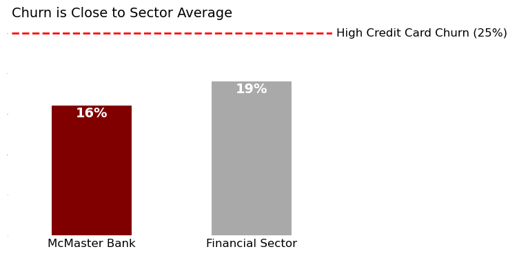

```python
import matplotlib.pyplot as plt

fig, ax = plt.subplots(figsize=(6, 4))
ax = (
    df_attrition_rate_plot
    .query("~type.str.contains('High')")
    .set_index('type')
    ['proportion']
    .plot
    .bar(ax=ax, rot=0, label='', color=['maroon', 'darkgrey'])
)
for container in ax.containers:
    ax.bar_label(
        container,
        label_type='edge',
        padding=-15,
        fmt='%.0f%%',
        fontsize=14,
        fontweight='bold',
        color='white',
    )
ax.axhline(
    y=25,
    color='red',
    linestyle='--',
    linewidth=2,
    label='High Credit Card Churn (25%)',
)
ax.legend(
    frameon=False,
    handletextpad=0.2,
    handlelength=0,
    loc='upper left',
    fontsize=12,
    bbox_to_anchor=(0.975, 1.025)
)
ax.set_title(
    'Churn is Close to Sector Average', loc='left', fontsize=14
)
ax.set_xlabel(None)
ax.spines['top'].set_visible(False)
ax.spines['right'].set_visible(False)
ax.spines['bottom'].set_visible(False)
ax.spines['left'].set_visible(False)
ax.tick_params(axis='x', labelsize=12, length=0)
ax.tick_params(axis='y', labelsize=0, length=0)
```

**Observations**

1. Credit card churn is observed in 16% of customers. This is
   - **just below** the [industry average churn rate for the financial sector of 19%](https://billingplatform.com/blog/average-churn-rate-by-industry)
   - below the [standard for high credit card churn of 25-30%](https://uxpressia.com/blog/how-to-approach-customer-churn-measurement-in-banking)

The total number of customers and total Customer Lifetime Value (CLV) are shown below for churned and existing customers

```python
%%time
df_attrition_stats = (
    df
    .groupby('is_churned')
    .agg({'clv': ['sum', 'count']})
    .set_axis(['clv_total', 'num_customers'], axis=1)
    .reset_index()
    .assign(
        clf_fraction=lambda df: (
            (df['clv_total']/df['clv_total'].sum()).mul(100)
        ),
        clv_per_customer=lambda df: df['clv_total']/df['num_customers'],
    )
)
df_attrition_stats
```

```
CPU times: user 6.39 ms, sys: 23 μs, total: 6.41 ms
Wall time: 5.84 ms
```

|  | is_churned | clv_total | num_customers | clf_fraction | clv_per_customer |
| --- | --- | --- | --- | --- | --- |
| 0 | False | 7452624.118 | 8500 | 90.01784 | 876.779308 |
| 1 | True | 826428.2668 | 1627 | 9.98216 | 507.946077 |

One common way to calculate the customer churn impact is to calculate the lost CLV per churned customer and add the replacement cost (CAC). The average CAC for a credit card customer is approximately [167](https://firstpagesage.com/seo-blog/average-customer-acquisition-cost-cac-in-banking/) USD or ~200 CAD. The total impact of churn is estimated below for sample of data provided by McMaster Bank

```python
(
    df_attrition_stats
    .reset_index(drop=True)
    .assign(
        impact_per_customer=lambda df: df['clv_per_customer']+replacement_cost,
        impact_total=lambda df: (
            df['clv_total']+df['num_customers'].mul(replacement_cost)
        ),
    )
)
```

|  | is_churned | clv_total | num_customers | clf_fraction | clv_per_customer | impact_per_customer | impact_total |
| --- | --- | --- | --- | --- | --- | --- | --- |
| 0 | False | 7452624.118 | 8500 | 90.01784 | 876.779308 | 1076.779308 | 9152624.118 |
| 1 | True | 826428.2668 | 1627 | 9.98216 | 507.946077 | 707.946077 | 1151828.2668 |

**Observations**

1. Approximately 10% of customer lifetime value is lost due to the 16% churn rate over the past 12 months in the random sample of customer data. The impact to the client (i.e. to the bank's credit card division) is a loss of approximately 508 dollars of customer lifetime value (per customer). When the cost to acquire a new customer is taken into account this adds up to a loss of 708 dollars per customer, or 1,151,828 dollars overall, due to churn.

The CLV of retained customers is shown below

```python
df_attrition_stats.query("is_churned == False").reset_index(drop=True)
```

|  | is_churned | clv_total | num_customers | clf_fraction | clv_per_customer |
| --- | --- | --- | --- | --- | --- |
| 0 | False | 7452624.118 | 8500 | 90.01784 | 876.779308 |

```python
df_attrition_stats_plot = pd.concat(
    [
        (
            df_attrition_stats
            .query("is_churned == False")
            [['clv_per_customer']]
            .assign(type='McMaster Bank')
        ),
        pd.DataFrame.from_records(
            [
                {
                    'clv_per_customer': 808,
                    'type': 'Credit Card Customers (Financial Sector)',
                }
            ]
        )
    ],
    ignore_index=True,
)
df_attrition_stats_plot
```

|  | clv_per_customer | type |
| --- | --- | --- |
| 0 | 876.779308 | McMaster Bank |
| 1 | 808.0 | Credit Card Customers (Financial Sector) |

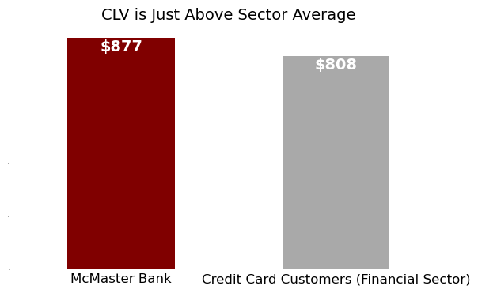

```python
fig, ax = plt.subplots(figsize=(7, 4))
ax = (
    df_attrition_stats_plot
    .set_index('type')
    ['clv_per_customer']
    .plot
    .bar(ax=ax, rot=0, label='', width=0.5, color=['maroon', 'darkgrey'])
)
for container in ax.containers:
    ax.bar_label(
        container,
        fmt='$%.0f',
        label_type='edge',
        color='white',
        padding=-15,
        fontsize=14,
        fontweight='bold',
    )
ax.set_title(
    'CLV is Just Above Sector Average', loc='center', fontsize=14
)
ax.set_xlabel(None)
ax.spines['top'].set_visible(False)
ax.spines['right'].set_visible(False)
ax.spines['bottom'].set_visible(False)
ax.spines['left'].set_visible(False)
ax.tick_params(axis='x', labelsize=12, length=0)
ax.tick_params(axis='y', labelsize=0, length=0)
```

**Observations**

1. The CLV is **just above** the [industry standard for credit card customers of $808](https://focus-digital.co/average-customer-lifetime-value-for-financial-services/).